# Diamonds_Part1

andreafernandes

29 March 2016

### Diamonds Dataset. Project Part 1

#### Using the diamonds dataset to practice a few EDA techniques and tools.

Working through the exercises in Problem Set 3: Exploratory Data Analysis with R

**Exercise 1** a) Load the diamonds data set in R studio (and ggplot package)

```r
library(ggplot2)
data(diamonds)
```

2. How many observations are in the dataset?
3. How may variables are in the data set?

```r
dim(diamonds) # 53940 obs    10 vars
```

[output not shown]

4. How many ordered factors are in the data set?

```r
str(diamonds) # 3
```

```
## Classes 'tbl_df', 'tbl' and 'data.frame':    53940 obs. of  10 variables:
##  $ carat  : num  0.23 0.21 0.23 0.29 0.31 0.24 0.24 0.26 0.22 0.23 ...
##  $ cut    : Ord.factor w/ 5 levels "Fair"<"Good"<..: 5 4 2 4 2 3 3 3 1 3 ...
##  $ color  : Ord.factor w/ 7 levels "D"<"E"<"F"<"G"<..: 2 2 2 6 7 7 6 5 2 5 ...
##  $ clarity: Ord.factor w/ 8 levels "I1"<"SI2"<"SI1"<..: 2 3 5 4 2 6 7 3 4 5 ...
##  $ depth  : num  61.5 59.8 56.9 62.4 63.3 62.8 62.3 61.9 65.1 59.4 ...
##  $ table  : num  55 61 65 58 58 57 57 55 61 61 ...
##  $ price  : int  326 326 327 334 335 336 336 337 337 338 ...
##  $ x      : num  3.95 3.89 4.05 4.2 4.34 3.94 3.95 4.07 3.87 4 ...
##  $ y      : num  3.98 3.84 4.07 4.23 4.35 3.96 3.98 4.11 3.78 4.05 ...
##  $ z      : num  2.43 2.31 2.31 2.63 2.75 2.48 2.47 2.53 2.49 2.39 ...
```

5. What letter represents the best color for a diamond?

```r
table(diamonds$color) # D
```

[output not shown]

A screenshot of the data:

```
##   carat       cut color clarity depth table price    x    y    z
## 1  0.23     Ideal     E     SI2  61.5    55   326 3.95 3.98 2.43
## 2  0.21   Premium     E     SI1  59.8    61   326 3.89 3.84 2.31
## 3  0.23      Good     E     VS1  56.9    65   327 4.05 4.07 2.31
## 4  0.29   Premium     I     VS2  62.4    58   334 4.20 4.23 2.63
## 5  0.31      Good     J     SI2  63.3    58   335 4.34 4.35 2.75
## 6  0.24 Very Good     J    VVS2  62.8    57   336 3.94 3.96 2.48
```

**Exercise 2** a) Create a histogram of the price of all the diamonds in the dataset

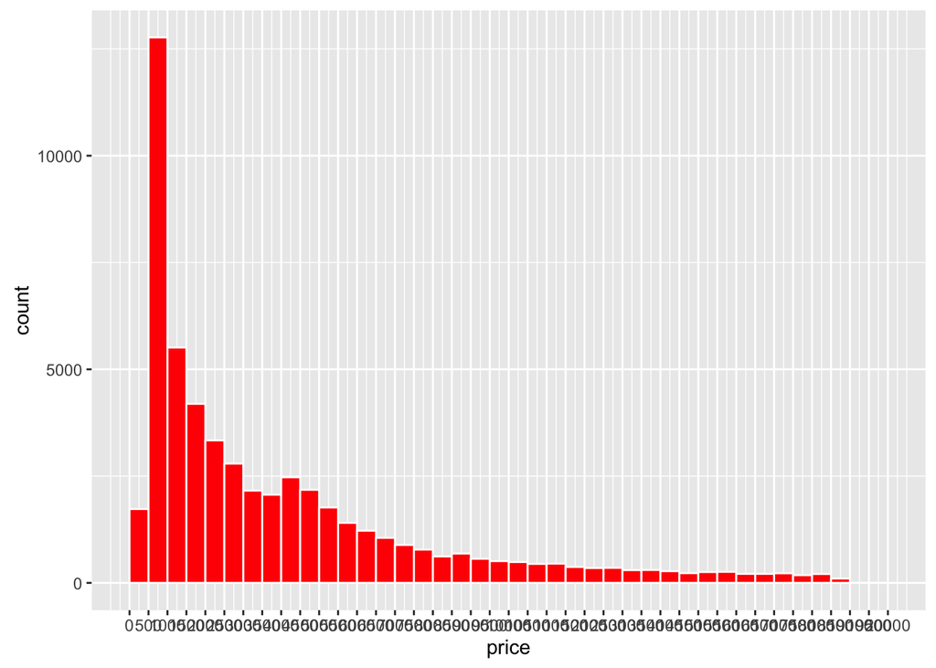

```r
qplot(x = price, data =  diamonds,
      color = I('white'), fill = I('#FF0000'),
      binwidth =  500) +
      scale_x_continuous(lim = c(0, 20000),
                         breaks = seq(0, 20000, 500))
```

2. Describe the shape and center of the price distribution

```
##    Min. 1st Qu.  Median    Mean 3rd Qu.    Max.
##     326     950    2401    3933    5324   18820
```

3. How many diamonds cost less than $500?

```r
table(diamonds$price < 500) #1729
```

[output not shown]

4. How many diamonds cost less than $250?

```r
table(diamonds$price < 250) # 0
```

```
##
## FALSE
## 53940
```

5. How many diamonds cost 15000 or more?

```r
table(diamonds$price >= 15000) #1656
```

```
##
## FALSE  TRUE
## 52284  1656
```

6. Explore the largest peak in the price histogram:

   The largest peak is between 500 and 1000

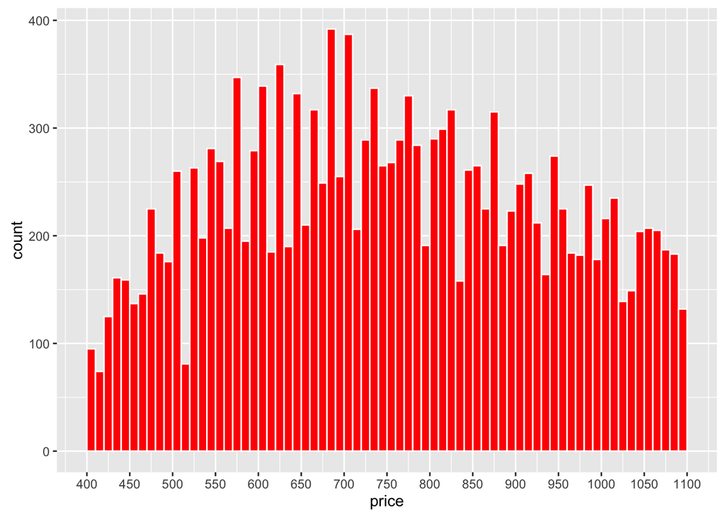

```r
qplot(x = price, data =  diamonds,
      color = I('white'), fill = I('#FF0000'),
      binwidth =  10) +
      scale_x_continuous(lim = c(400, 1100),
                         breaks = seq(400, 1100, 50))
```

```r
ggsave('priceHistogram.png', last_plot())
```

**Exercise 3** a) Plot histograms of diamond prices by cut

```
Histograms
```

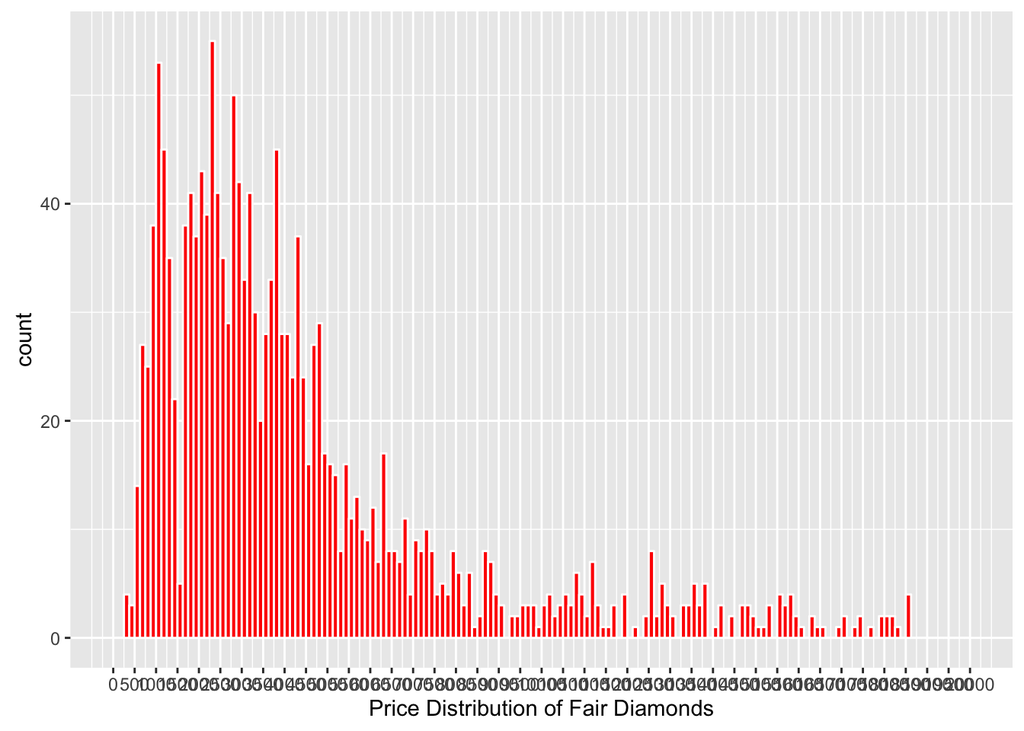

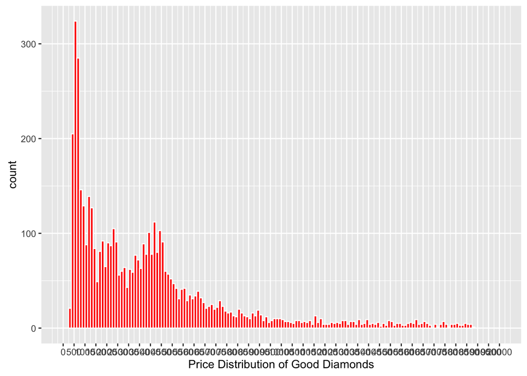

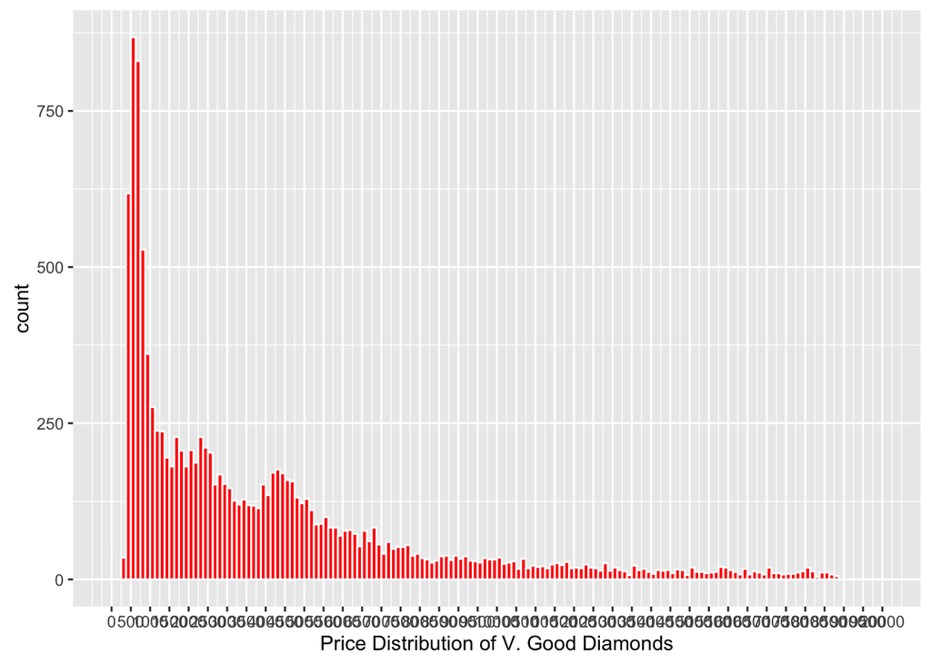

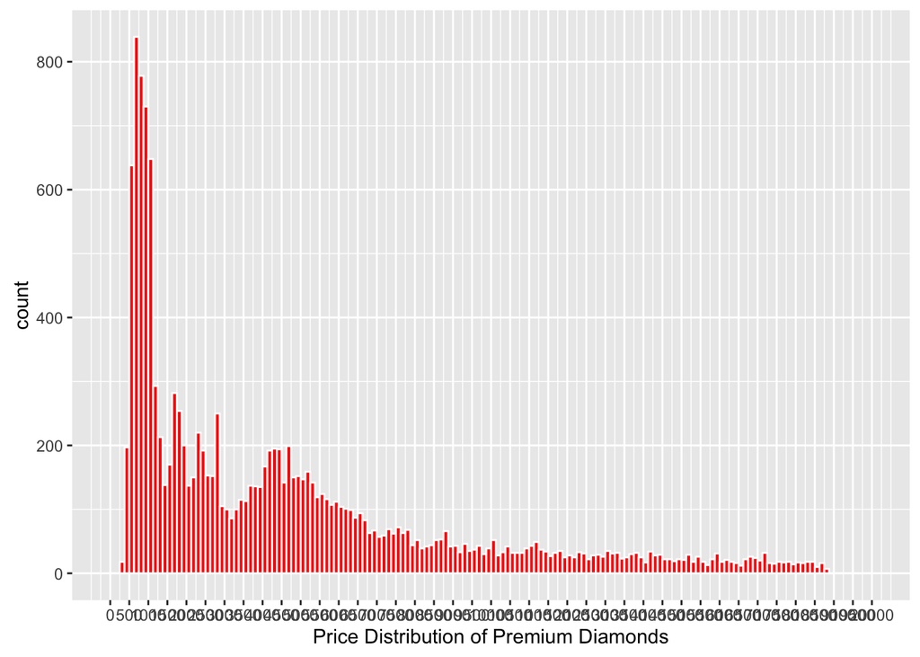

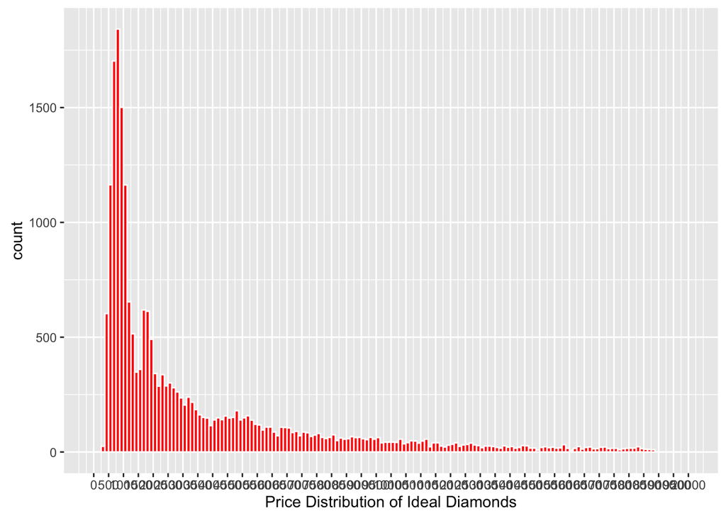

2. Answer the questions below:
   1. Which cut has the highest priced diamond?
   2. Which cut has the lowest priced diamond?
   3. Which cut has the lowest median price?

```r
by(diamonds$price, diamonds$cut, summary, digits = max(getOption('digits')))
```

```
## diamonds$cut: Fair
##      Min.   1st Qu.    Median      Mean   3rd Qu.      Max.
##   337.000  2050.250  3282.000  4358.758  5205.500 18574.000
## --------------------------------------------------------
## diamonds$cut: Good
##      Min.   1st Qu.    Median      Mean   3rd Qu.      Max.
##   327.000  1145.000  3050.500  3928.864  5028.000 18788.000
## --------------------------------------------------------
## diamonds$cut: Very Good
##     Min.  1st Qu.   Median     Mean  3rd Qu.     Max.
##   336.00   912.00  2648.00  3981.76  5372.75 18818.00
## --------------------------------------------------------
## diamonds$cut: Premium
##      Min.   1st Qu.    Median      Mean   3rd Qu.      Max.
##   326.000  1046.000  3185.000  4584.258  6296.000 18823.000
## --------------------------------------------------------
## diamonds$cut: Ideal
##      Min.   1st Qu.    Median      Mean   3rd Qu.      Max.
##   326.000   878.000  1810.000  3457.542  4678.500 18806.000
```

```r
# a) Premium, b) Premium and Ideal , c) Ideal
```

3. Add a parameter to facet_wrap so that the y-axis in the histograms is not fixed. You want the y-axis to be different for each histogram.

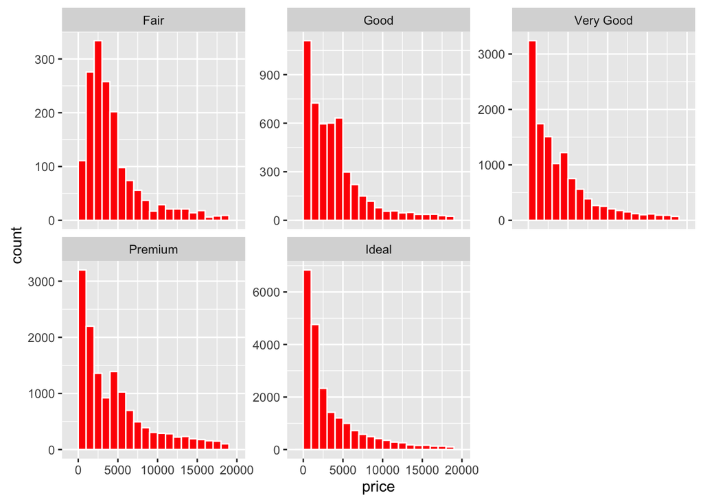

```r
qplot(x = price, data = diamonds,
      color = I('white'), fill = I('#FF0000'),
      binwidth =  1000) +
  facet_wrap(~cut,
             scales= "free_y")
```

4. Create a histogram of price per carat and facet it by cut. You can make adjustments to the code from the previous exercise to get started.

Adjust the bin width and transform the scale of the x-axis using log10.

[figure not shown]

```r
qplot(x = price/carat, data =  diamonds,
      color = I('white'), fill = I('#FF0000'),
      binwidth = 125) +
      facet_wrap(~cut,
                 scales = "free") +
      scale_x_log10() +
      scale_x_continuous(lim = c(1000, 15000), breaks = seq(1000, 15000, 1000))
```

**Exercise 4** Investigate the price of diamonds using box plots, numerical summaries, and one of the following categorical variables: cut, clarity, or color.

*Investigating Price by Color*

BOXPLOT BY COLOR

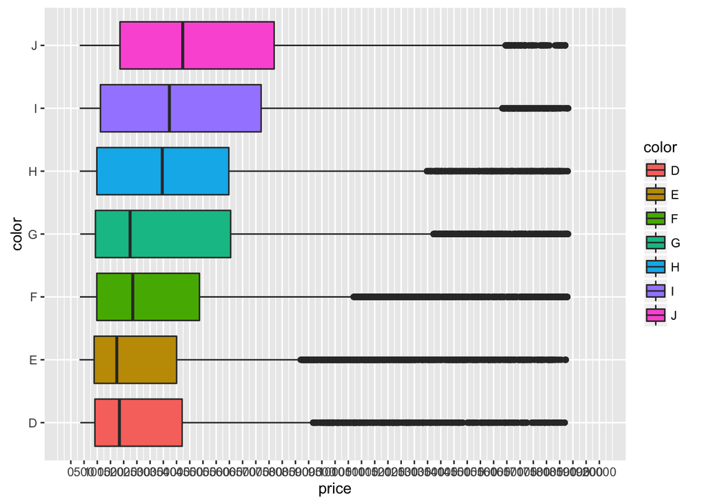

```r
qplot(x = color, y = price,
      data = subset(diamonds),
      geom = 'boxplot',
      fill = color) +
      coord_flip() +
      scale_y_continuous(lim = c(0, 20000), breaks = seq(0, 20000, 500))
```

Summarising boxplot: The letter that represents the best color for a diamond is D.

```
  - This plot is not very informative.
  - Colors D to J all have similar overall ranges
  - The price of J varies more than D; The IQR of D lies between ~$1000 and ~$4500, while the IQR of J lies between ~$1500 and $7500
```

If I compare price per carat by color, this may be able to give an indication of the value of each color. So if I have one carat of color D and one carat of color J, is that the same price?

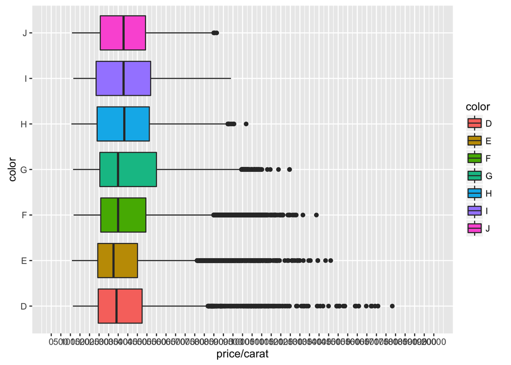

```r
qplot(x = color, y = price/carat,
      data = subset(diamonds),
      geom = 'boxplot',
      fill = color) +
      coord_flip() +
      scale_y_continuous(lim = c(0, 20000), breaks = seq(0, 20000, 500))
```

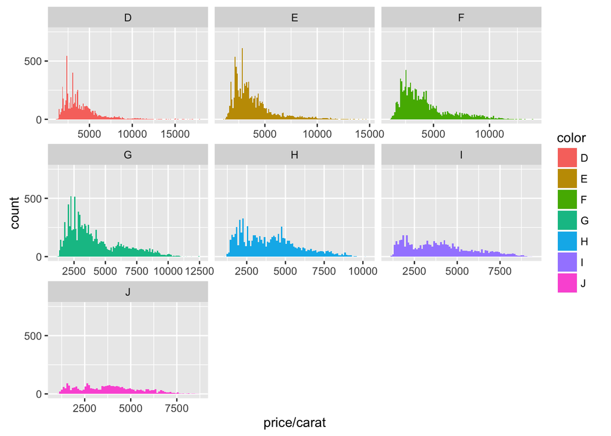

```r
qplot(x = price/carat,
      data = diamonds,
      binwidth = 100,
      #geom = 'boxplot',
      fill = color) +
      #coord_flip() +
      scale_y_continuous(lim = c(0, 750), breaks = seq(0, 750, 500)) +
      #scale_x_continuous(lim = c(0, 8000), breaks = seq(0, 8000, 500)) +
      facet_wrap(~color, scales = "free_x")
```

Summary: These plots seems to show us a trend.

```
Diamonds of color J seem to have a more normal distribution than Diamond of color D.
There are more expensive diamonds of color D than there are of color J.
```

**Exercise 5**

```
## diamonds$color: D
##      Min.   1st Qu.    Median      Mean   3rd Qu.      Max.
##   357.000   911.000  1838.000  3169.954  4213.500 18693.000
## --------------------------------------------------------
## diamonds$color: E
##      Min.   1st Qu.    Median      Mean   3rd Qu.      Max.
##   326.000   882.000  1739.000  3076.752  4003.000 18731.000
## --------------------------------------------------------
## diamonds$color: F
##      Min.   1st Qu.    Median      Mean   3rd Qu.      Max.
##   342.000   982.000  2343.500  3724.886  4868.250 18791.000
## --------------------------------------------------------
## diamonds$color: G
##      Min.   1st Qu.    Median      Mean   3rd Qu.      Max.
##   354.000   931.000  2242.000  3999.136  6048.000 18818.000
## --------------------------------------------------------
## diamonds$color: H
##      Min.   1st Qu.    Median      Mean   3rd Qu.      Max.
##   337.000   984.000  3460.000  4486.669  5980.250 18803.000
## --------------------------------------------------------
## diamonds$color: I
##      Min.   1st Qu.    Median      Mean   3rd Qu.      Max.
##   334.000  1120.500  3730.000  5091.875  7201.750 18823.000
## --------------------------------------------------------
## diamonds$color: J
##      Min.   1st Qu.    Median      Mean   3rd Qu.      Max.
##   335.000  1860.500  4234.000  5323.818  7695.000 18710.000
```

**Exercise 6** Investigate the weight of the diamonds (carat) using a frequency polygon. What carat size has a count greater than 2000?

```r
sort(table(diamonds$carat)) # 1.01, 0.31, 0.3
```

```
##
## 2.59 2.64 2.65 2.67  2.7 2.71 2.77 3.02 3.05 3.11 3.22 3.24  3.4  3.5 3.51
##    1    1    1    1    1    1    1    1    1    1    1    1    1    1    1
## 3.65 3.67    4 4.13  4.5 5.01 1.92 2.68 2.75  2.8 3.04 4.01 1.85 1.94 1.95
##    1    1    1    1    1    1    2    2    2    2    2    2    3    3    3
## 1.99 2.46 2.47 2.49 2.55 2.56 2.57 2.58  2.6 2.61 2.63 2.66 2.72 2.74 1.84
##    3    3    3    3    3    3    3    3    3    3    3    3    3    3    4
## 1.88 1.89 1.96 1.97 2.44 2.45 0.22 1.98 2.34 2.41 1.93 2.37 2.43 1.48 1.87
##    4    4    4    4    4    4    5    5    5    5    6    6    6    7    7
##  1.9 2.35 2.39 2.36 2.38 2.42 2.53    3 0.21 1.81 1.86 2.33 2.48 2.52 2.54
##    7    7    7    8    8    8    8    8    9    9    9    9    9    9    9
## 1.49  0.2 1.78 1.91 2.27 1.82 2.23 2.31  2.4 3.01 1.45 1.79 2.26 2.24 2.32
##   11   12   12   12   12   13   13   13   13   14   15   15   15   16   16
## 1.77 2.29  2.5 2.51 1.44 1.46 1.83 2.17 2.25 1.43 1.68 2.28 0.89 1.47  1.8
##   17   17   17   17   18   18   18   18   18   19   19   20   21   21   21
## 2.13  2.3 2.15 2.19 0.88 0.99 2.21 1.69 0.68 1.42 1.67 2.12 2.16 0.69 1.38
##   21   21   22   22   23   23   23   24   25   25   25   25   25   26   26
## 2.22 1.76 1.66 0.87 0.98 2.18 1.65  2.2 0.86 1.39 1.41 1.74 2.08 1.64 2.11
##   27   28   30   31   31   31   32   32   34   36   40   40   41   43   43
## 0.49 2.09 1.37 0.66 0.67 2.14 1.36  1.4 1.63 1.75 2.07 1.73  2.1 1.72 0.94
##   45   45   46   48   48   48   50   50   50   50   50   52   52   57   59
## 0.97 2.06 1.62 0.85 0.48 0.84 1.61 0.65 0.95 2.05 1.34 1.35 0.64 2.04 1.33
##   59   60   61   62   63   64   64   65   65   67   68   77   80   86   87
## 1.32 1.58 1.59  1.6 0.47 1.29 0.63 0.96 1.28 1.57 1.56 0.45 1.17 1.71  1.3
##   89   89   89   95   99  101  102  103  106  106  109  110  110  119  122
## 2.03 1.18 1.55 1.19 0.29 0.83 1.31 1.27 0.62 0.82 0.93 1.26 1.15 0.79 1.16
##  122  123  124  126  130  131  133  134  135  140  142  146  149  155  172
## 1.54 2.02 0.46 0.78 1.25 0.28 0.81 0.61 1.14 0.25 0.44  1.7 1.53 0.92  0.6
##  174  177  178  187  187  198  200  204  207  212  212  215  220  226  228
## 0.27 1.24 1.08 1.13 0.75 0.76 0.77 1.12 0.26 0.24    2  1.1 1.23 0.59  0.8
##  233  236  246  246  249  251  251  251  253  254  265  278  279  282  284
## 1.09 0.23 1.22 1.11 0.58 0.74 1.07 1.05 1.06 1.52 0.37 0.39 0.57 2.01 1.21
##  287  293  300  308  310  322  342  361  373  381  394  398  430  440  473
## 1.04 0.43 0.56 0.73 0.55 1.03 0.91 0.36 0.54  1.2 0.35 0.38 0.42 0.53 0.72
##  475  488  492  492  496  523  570  572  625  645  667  670  706  709  764
##  1.5 1.51 0.52 1.02 0.34 0.51 0.33  0.5 0.71  0.4 0.41  0.9    1 0.32  0.7
##  793  807  817  883  910 1127 1189 1258 1294 1299 1382 1485 1558 1840 1981
## 1.01 0.31  0.3
## 2242 2249 2604
```

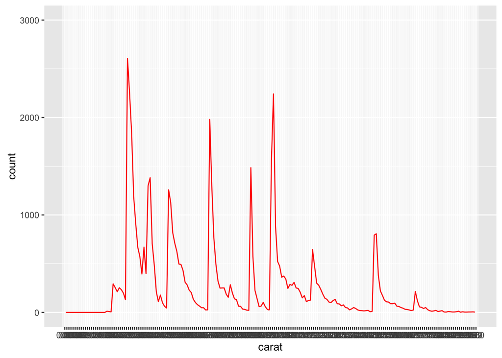

```r
qplot(x = carat, data = diamonds, binwidth = 0.01, color = I('red'), geom = "freqpoly") +
      scale_x_continuous(lim = c(0, 2), breaks = seq(0, 2, 0.01)) +
      scale_y_continuous(lim = c(0, 3000), breaks = seq(0, 3000, 1000))
```